# Statistical Foundations for Data Science - HW8 - Sean Kennedy

Sean Kennedy

7/7/2019

### Question 1

# scatter plot the data

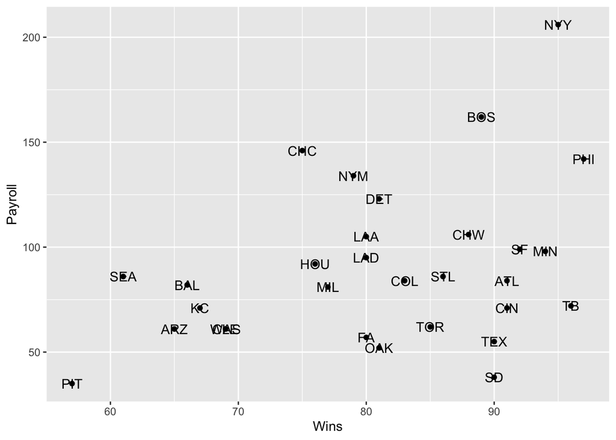

```r
baseball_data = read.csv('Baseball_Data.csv')
ggplot(data=baseball_data, aes(x = baseball_data$Wins, y=baseball_data$Payroll)) + geom_point() + labs(x='Wins', y='Payroll') + geom_text(label=baseball_data$TEAM)
```

### Question 2: Calc the Correlation Coeffecient

```r
  cor(baseball_data$Payroll, baseball_data$Wins)
```

```
## [1] 0.366231
```

Ooof - 0.6 was a crappy guess. Too much time considering that New York Yankee payroll as being indicitive of the overall trend. Damn Yankees :)

## Question 3: Remove SD and re-run

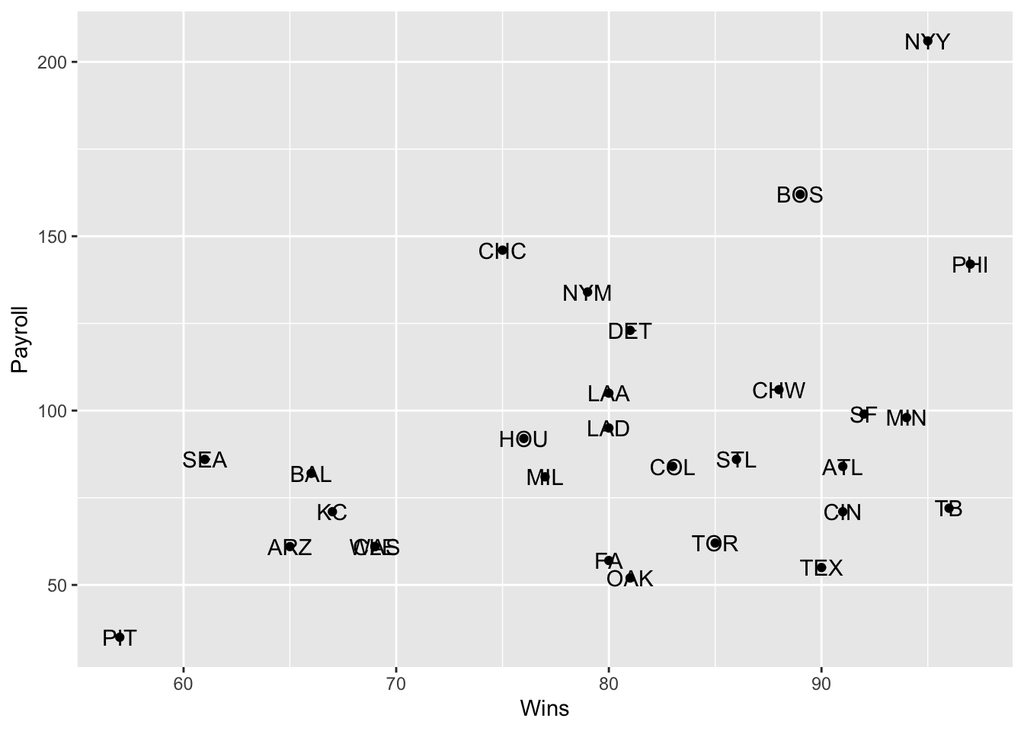

```r
no_sd = sqldf("SELECT * FROM baseball_data WHERE TEAM <> 'SD'")
ggplot(data=no_sd, aes(x = no_sd$Wins, y=no_sd$Payroll)) + geom_point() + labs(x='Wins', y='Payroll') + geom_text(label=no_sd$TEAM)
```

```r
cor(no_sd$Payroll, no_sd$Wins)
```

```
## [1] 0.4255494
```

## Question 4

The commissioner is cherry picking teams when making his argument with regard to payroll. While it is true that TEX had a great win total with a low payroll, and CHC were terrible with a very high payroll. To say that those two teams are reprensetative of the dataset as a while is very misleading. 2 of the top 4 teams for payroll were in the top 4 for wins. Clearly, spending more can have its advantages if the money is spent wisely. Having higher payroll generally allows teams to absorb mistakes made in free agency more easily, which is clearly an advantage, but a smart GM that budgets salary properly and drafts well will have a strong chance to be successful. As always, there is more to the story than just payroll and there is always more to a story than 2 datapoints out of 30 possible.

## Question 5

The population of this dataset is all MLB teams, hence this cannot be random sample of the data. If we were to randomly select 10 teams from the overall population and run the same analysis, then it would be a random sample.

## SAS CODE

*base ball scatter; proc sgplot data=WORK.baseball; scatter x=Wins y=Payroll / datalabel=TEAM; xaxis grid display=(nolabel); yaxis grid; run;

*calc pearson correlations; proc corr data=WORK.baseball; run;